## Gene set enrichment analysis

**Gene set enrichment analysis** (also **functional enrichment analysis**) is a method to identify set of **genes** or **proteins** that are over-represented in a large set of genes or proteins and may have association with disease phenotype. Gene sets are usually specific genes that are involved in a particular biological function or particular location in cells. To observe several gene sets refer to some of the databases that provide them such as **GO**, **KEGG**, **MSigDB**. Researchers performing high-throughput experiments usually perform enrichemnt analysis to see if a specific set of gene is overrepresented in their differentially expressed genes or not. To read a good introduction about enrichment analysis read [wikipedia](https://en.wikipedia.org/wiki/Gene_set_enrichment_analysis).

To see the major collection of gene sets of MSigDB database refer to the [website](https://www.gsea-msigdb.org/gsea/msigdb). Similarly gene sets from other databases such as KEGG and GO are accessible by database website. For example to see the gene set of *Toll-like receptor binding* in GO refer to [GO website](http://amigo.geneontology.org/amigo/term/GO:0035325).

Furthermore, the gene sets of MSigDB in dataformat is packed in the R package **msigdbr** that can be used directly with **clusterProfiler**.

```r
library(msigdbr)
msigdbr_species()
```

```
## # A tibble: 20 x 2
##    species_name                species_common_name
##    <chr>                       <chr>
##  1 Anolis carolinensis         Carolina anole, green anole
##  2 Bos taurus                  bovine, cattle, cow, dairy cow, domestic cattle,…
##  3 Caenorhabditis elegans      roundworm
##  4 Canis lupus familiaris      dog, dogs
##  5 Danio rerio                 leopard danio, zebra danio, zebra fish, zebrafish
##  6 Drosophila melanogaster     fruit fly
##  7 Equus caballus              domestic horse, equine, horse
##  8 Felis catus                 cat, cats, domestic cat
##  9 Gallus gallus               bantam, chicken, chickens, Gallus domesticus
## 10 Homo sapiens                human
## 11 Macaca mulatta              rhesus macaque, rhesus macaques, Rhesus monkey, …
## 12 Monodelphis domestica       gray short-tailed opossum
## 13 Mus musculus                house mouse, mouse
## 14 Ornithorhynchus anatinus    duck-billed platypus, duckbill platypus, platypus
## 15 Pan troglodytes             chimpanzee
## 16 Rattus norvegicus           brown rat, Norway rat, rat, rats
## 17 Saccharomyces cerevisiae    baker's yeast, brewer's yeast, S. cerevisiae
## 18 Schizosaccharomyces pombe … <NA>
## 19 Sus scrofa                  pig, pigs, swine, wild boar
## 20 Xenopus tropicalis          tropical clawed frog, western clawed frog
```

Available collections of gene sets is MSigDB;

```r
library(msigdbr)
db <- msigdbr_collections()
db[0:20, ]
```

```
## # A tibble: 20 x 3
##    gs_cat gs_subcat         num_genesets
##    <chr>  <chr>                    <int>
##  1 C1     ""                         278
##  2 C2     "CGP"                     3368
##  3 C2     "CP"                        29
##  4 C2     "CP:BIOCARTA"              292
##  5 C2     "CP:KEGG"                  186
##  6 C2     "CP:PID"                   196
##  7 C2     "CP:REACTOME"             1604
##  8 C2     "CP:WIKIPATHWAYS"          615
##  9 C3     "MIR:MIR_Legacy"           221
## 10 C3     "MIR:MIRDB"               2377
## 11 C3     "TFT:GTRD"                 523
## 12 C3     "TFT:TFT_Legacy"           610
## 13 C4     "CGN"                      427
## 14 C4     "CM"                       431
## 15 C5     "GO:BP"                   7481
## 16 C5     "GO:CC"                    996
## 17 C5     "GO:MF"                   1708
## 18 C5     "HPO"                     4813
## 19 C6     ""                         189
## 20 C7     "IMMUNESIGDB"             4872
```

As it is clear, the KEGG database has 186 gene sets. To see all the gene sets of KEGG for human;

```r
library(msigdbr)
df <- msigdbr(species = 'Homo sapiens', category = 'C2', subcategory = 'CP:KEGG')
str(df)
```

```
## tibble[,15] [16,069 × 15] (S3: tbl_df/tbl/data.frame)
##  $ gs_cat            : chr [1:16069] "C2" "C2" "C2" "C2" ...
##  $ gs_subcat         : chr [1:16069] "CP:KEGG" "CP:KEGG" "CP:KEGG" "CP:KEGG" ...
##  $ gs_name           : chr [1:16069] "KEGG_ABC_TRANSPORTERS" "KEGG_ABC_TRANSPORTERS" "KEGG_ABC_TRANSPORTERS" "KEGG_ABC_TRANSPORTERS" ...
##  $ gene_symbol       : chr [1:16069] "ABCA1" "ABCA10" "ABCA12" "ABCA13" ...
##  $ entrez_gene       : int [1:16069] 19 10349 26154 154664 20 21 24 23461 23460 10347 ...
##  $ ensembl_gene      : chr [1:16069] "ENSG00000165029" "ENSG00000154263" "ENSG00000144452" "ENSG00000179869" ...
##  $ human_gene_symbol : chr [1:16069] "ABCA1" "ABCA10" "ABCA12" "ABCA13" ...
##  $ human_entrez_gene : int [1:16069] 19 10349 26154 154664 20 21 24 23461 23460 10347 ...
##  $ human_ensembl_gene: chr [1:16069] "ENSG00000165029" "ENSG00000154263" "ENSG00000144452" "ENSG00000179869" ...
##  $ gs_id             : chr [1:16069] "M11911" "M11911" "M11911" "M11911" ...
##  $ gs_pmid           : chr [1:16069] "" "" "" "" ...
##  $ gs_geoid          : chr [1:16069] "" "" "" "" ...
##  $ gs_exact_source   : chr [1:16069] "hsa02010" "hsa02010" "hsa02010" "hsa02010" ...
##  $ gs_url            : chr [1:16069] "http://www.genome.jp/kegg/pathway/hsa/hsa02010.html" "http://www.genome.jp/kegg/pathway/hsa/hsa02010.html" "http://www.genome.jp/kegg/pathway/hsa/hsa02010.html" "http://www.genome.jp/kegg/pathway/hsa/hsa02010.html" ...
##  $ gs_description    : chr [1:16069] "ABC transporters" "ABC transporters" "ABC transporters" "ABC transporters" ...
```

```r
data.frame(table(df[, 3]))
```

```
##                                                                Var1 Freq
## 1                                             KEGG_ABC_TRANSPORTERS   61
## 2                                       KEGG_ACUTE_MYELOID_LEUKEMIA   59
## 3                                            KEGG_ADHERENS_JUNCTION   81
## 4                              KEGG_ADIPOCYTOKINE_SIGNALING_PATHWAY   85
## 5                   KEGG_ALANINE_ASPARTATE_AND_GLUTAMATE_METABOLISM   33
## 6                    KEGG_ALDOSTERONE_REGULATED_SODIUM_REABSORPTION   42
## 7                                          KEGG_ALLOGRAFT_REJECTION  153
## 8                              KEGG_ALPHA_LINOLENIC_ACID_METABOLISM   20
## 9                                           KEGG_ALZHEIMERS_DISEASE  192
## 10                 KEGG_AMINO_SUGAR_AND_NUCLEOTIDE_SUGAR_METABOLISM   46
## 11                                 KEGG_AMINOACYL_TRNA_BIOSYNTHESIS   54
## 12                           KEGG_AMYOTROPHIC_LATERAL_SCLEROSIS_ALS   65
## 13                         KEGG_ANTIGEN_PROCESSING_AND_PRESENTATION  497
## 14                                                   KEGG_APOPTOSIS   98
```

[output cut: 172 more lines]

To see the list of genes in a particular KEGG gene set such as KEGG_CELL_CYCLE;

```r
genes <- df[df[,3] == 'KEGG_CELL_CYCLE', ][, c(3, 4)]
data.frame(genes)
```

```
##             gs_name gene_symbol
## 1   KEGG_CELL_CYCLE        ABL1
## 2   KEGG_CELL_CYCLE      ANAPC1
## 3   KEGG_CELL_CYCLE     ANAPC10
## 4   KEGG_CELL_CYCLE     ANAPC11
## 5   KEGG_CELL_CYCLE     ANAPC13
## 6   KEGG_CELL_CYCLE      ANAPC2
## 7   KEGG_CELL_CYCLE      ANAPC4
## 8   KEGG_CELL_CYCLE      ANAPC5
## 9   KEGG_CELL_CYCLE      ANAPC7
## 10  KEGG_CELL_CYCLE         ATM
## 11  KEGG_CELL_CYCLE         ATR
## 12  KEGG_CELL_CYCLE        BUB1
## 13  KEGG_CELL_CYCLE       BUB1B
## 14  KEGG_CELL_CYCLE        BUB3
```

[output cut: 116 more lines]

### GO enrichemnt analysis

To perform Gene Ontology enrichment analysis first we need a sample vector of genes (Differentially expressed genes in our microarray test). For this purpose we use genelist data in DOSE package.

```r
library(DOSE)
data(geneList)
head(geneList)
```

```
##     4312     8318    10874    55143    55388      991
## 4.572613 4.514594 4.418218 4.144075 3.876258 3.677857
```

Among these genes we select only genes with foldchange more than two as our differentially expressed gene list.

```r
DEgenes <-geneList[abs(geneList) > 2 ]
length(DEgenes)
```

```
## [1] 207
```

```r
head(DEgenes)
```

```
##     4312     8318    10874    55143    55388      991
## 4.572613 4.514594 4.418218 4.144075 3.876258 3.677857
```

In order to perform ID conversion, Bioconductor provide annotation objects (OrgDb) for species.

```r
library('org.Hs.eg.db')
```

In this notebook we use clusterProfiler package in R to perform GSEA.

```r
library(clusterProfiler)
library(pathview)
library(enrichplot)
library(ggplot2)
```

In order to perform ID conversion on DEgenes, bitr function in clusterProfiler is used.

```r
DEgenes.symbols <- bitr(names(DEgenes), fromType = 'ENTREZID',
            toType = c('ENSEMBL', 'SYMBOL'), OrgDb = 'org.Hs.eg.db')
head(DEgenes.symbols)
```

```
##   ENTREZID         ENSEMBL SYMBOL
## 1     4312 ENSG00000196611   MMP1
## 2     8318 ENSG00000093009  CDC45
## 3    10874 ENSG00000109255    NMU
## 4    55143 ENSG00000134690  CDCA8
## 5    55388 ENSG00000065328  MCM10
## 6      991 ENSG00000117399  CDC20
```

To see the GO profile of a gene set at specific level groupGO is used.

```r
ggo <- groupGO(gene = names(DEgenes),
                OrgDb = org.Hs.eg.db,
                ont = 'CC',
                level = 3,
                readable = TRUE)
head(ggo)
```

```
##                    ID                    Description Count GeneRatio
## GO:0005886 GO:0005886                plasma membrane    55    55/207
## GO:0005628 GO:0005628              prospore membrane     0     0/207
## GO:0005789 GO:0005789 endoplasmic reticulum membrane     8     8/207
## GO:0019867 GO:0019867                 outer membrane     3     3/207
## GO:0031090 GO:0031090             organelle membrane    16    16/207
## GO:0034357 GO:0034357        photosynthetic membrane     0     0/207
##                                                                                                                                                                                                                                                                                                          …
## GO:0005886 S100A9/MELK/S100A8/MARCO/ASPM/CXCL10/LAMP3/CEP55/UGT8/UBE2C/…-DQA1/ADH1B/PDZK1/C7/ACKR1/COL17A1/PSD3/EMCN/SLC44A4/LRP2/NLGN4X/MAPT/ERBB4/CX3CR1/LAMP5/ABCA8/STEAP4/PTPRT/TMC5/CYBRD1
## GO:0005628
## GO:0005789                                                                                                                                                                                                                                                                                               …
## GO:0019867                                                                                                                                                                                                                                                                                               …
## GO:0031090                                                                                                                                                                                                                                                MARCO/BCL2A1/LAMP3/DUSP2/SLC2A6/DTL/NUDT1/MAOB/…
## GO:0034357
```

overrepresentation analysis is performed to see if a gene set is overrepresented in your gene list. To perform overrepresentation analysis use enrichGO:

```r
ego <- enrichGO(gene = names(DEgenes),
                universe = names(geneList),
                OrgDb = org.Hs.eg.db,
                ont = 'CC',
                pAdjustMethod = 'BH',
                pvalueCutoff = 0.01,
                qvalueCutoff = 0.05,
                readable = T)
head(ego)
```

```
##                    ID                              Description GeneRatio
## GO:0005819 GO:0005819                                  spindle    25/200
## GO:0005876 GO:0005876                      spindle microtubule    12/200
## GO:0000779 GO:0000779 condensed chromosome, centromeric region    15/200
## GO:0072686 GO:0072686                          mitotic spindle    15/200
## GO:0000775 GO:0000775           chromosome, centromeric region    18/200
## GO:0000776 GO:0000776                              kinetochore    15/200
##              BgRatio       pvalue     p.adjust       qvalue
## GO:0005819 272/11816 4.695505e-12 1.493171e-09 1.378996e-09
## GO:0005876  48/11816 1.623758e-11 2.581776e-09 2.384361e-09
## GO:0000779  91/11816 2.808998e-11 2.628919e-09 2.427899e-09
## GO:0072686  92/11816 3.306816e-11 2.628919e-09 2.427899e-09
## GO:0000775 154/11816 1.061302e-10 6.749884e-09 6.233756e-09
## GO:0000776 107/11816 3.047081e-10 1.614953e-08 1.491466e-08
##                                                                                                                                                         geneID
## GO:0005819 CDCA8/CDC20/KIF23/CENPE/ASPM/DLGAP5/SKA1/NUSAP1/TPX2/TACC3/NEK2/CDK1/MAD2L1/KIF18A/BIRC5/KIF11/TTK/AURKB/PRC1/KIFC1/KIF18B/KIF20A/AURKA/CCNB1/KIF4A
## GO:0005876                                                                             CENPE/SKA1/NUSAP1/CDK1/KIF18A/BIRC5/KIF11/AURKB/PRC1/KIF18B/AURKA/KIF4A
## GO:0000779                                                            CENPE/NDC80/HJURP/SKA1/NEK2/CENPM/CENPN/ERCC6L/MAD2L1/CDT1/BIRC5/NCAPG/AURKB/AURKA/CCNB1
## GO:0072686                                                           KIF23/CENPE/ASPM/SKA1/NUSAP1/TPX2/TACC3/CDK1/MAD2L1/KIF18A/KIF11/AURKB/KIFC1/KIF18B/AURKA
## GO:0000775                                           CDCA8/CENPE/NDC80/HJURP/SKA1/NEK2/CENPM/CENPN/ERCC6L/MAD2L1/KIF18A/CDT1/BIRC5/TTK/NCAPG/AURKB/AURKA/CCNB1
## GO:0000776                                                             CENPE/NDC80/HJURP/SKA1/NEK2/CENPM/CENPN/ERCC6L/MAD2L1/KIF18A/CDT1/BIRC5/TTK/AURKB/CCNB1
##            Count
## GO:0005819    25
## GO:0005876    12
## GO:0000779    15
## GO:0072686    15
## GO:0000775    18
## GO:0000776    15
```

gseGO is used to perform gene enrichment analysis of GO:

```r
DEgenes <- sort(DEgenes, decreasing = T)
gse <- gseGO(geneList = DEgenes,
        ont = 'ALL',
        keyType = 'ENTREZID',
        nPerm = 10000,
        minGSSize = 3,
        maxGSSize = 800,
        pvalueCutoff = 0.05,
        verbose = T,
        OrgDb = 'org.Hs.eg.db',
        pAdjustMethod = 'none')
```

```
## preparing geneSet collections...
```

```
## GSEA analysis...
```

```
## leading edge analysis...
```

```
## done...
```

```r
head(gse)
```

```
##            ONTOLOGY         ID                                   Description
## GO:0016043       BP GO:0016043               cellular component organization
## GO:0005634       CC GO:0005634                                       nucleus
## GO:0071840       BP GO:0071840 cellular component organization or biogenesis
## GO:0044260       BP GO:0044260      cellular macromolecule metabolic process
## GO:0005829       CC GO:0005829                                       cytosol
## GO:0043228       CC GO:0043228                non-membrane-bounded organelle
##            setSize enrichmentScore      NES       pvalue     p.adjust
## GO:0016043      89       0.4162542 3.129814 0.0001798561 0.0001798561
## GO:0005634      90       0.4377947 3.301679 0.0001799208 0.0001799208
## GO:0071840      90       0.4256495 3.210084 0.0001799208 0.0001799208
## GO:0044260      87       0.3191409 2.385668 0.0001810938 0.0001810938
## GO:0005829      69       0.3525206 2.550764 0.0001812908 0.0001812908
## GO:0043228      73       0.4432789 3.240839 0.0001823487 0.0001823487
##                qvalues rank                   leading_edge
## GO:0016043 0.006278009   95 tags=69%, list=46%, signal=65%
## GO:0005634 0.006278009  110 tags=78%, list=53%, signal=64%
## GO:0071840 0.006278009   95 tags=69%, list=46%, signal=66%
## GO:0044260 0.006278009   88 tags=60%, list=43%, signal=59%
## GO:0005829 0.006278009  110 tags=77%, list=53%, signal=54%
## GO:0043228 0.006278009  102 tags=77%, list=49%, signal=60%
##                                                                                                                                                                                                                                                                                                          …
## GO:0016043                                            4312/8318/55143/991/6280/9493/1062/3868/4605/9133/6279/10403…
## GO:0005634 8318/55143/55388/991/6280/2305/9493/1062/3868/4605/9833/9133…
## GO:0071840                                       4312/8318/55143/991/6280/9493/1062/3868/4605/9133/6279/10403…
## GO:0044260                                                                                                       4312/8318/55388/991/6280/2305/1062/4605/9833/9133/6279/8685/…
## GO:0005829                                                                                           55143/991/6280/9493/1062/3868/9133/6279/10403/23397/6278/797…
## GO:0043228                                                                        8318/55143/55388/991/6280/9493/1062/3868/4605/9133/6279/1040…
```

To draw dotplot use the dotplot function:

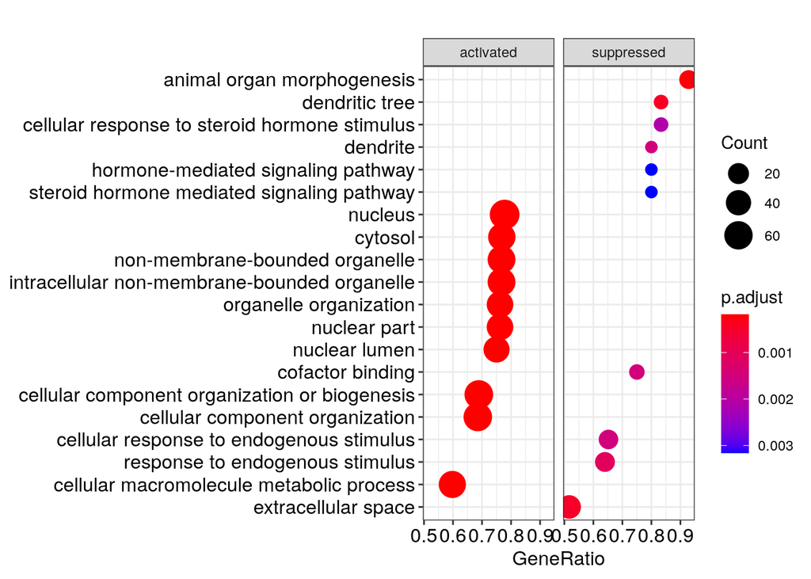

```r
require(DOSE)
dotplot(gse, showCategory = 10, split = '.sign') + facet_grid(.~.sign)
```

Use emapplot in enrichplot package to draw enrichment plot of gene enrichment analysis resutl.

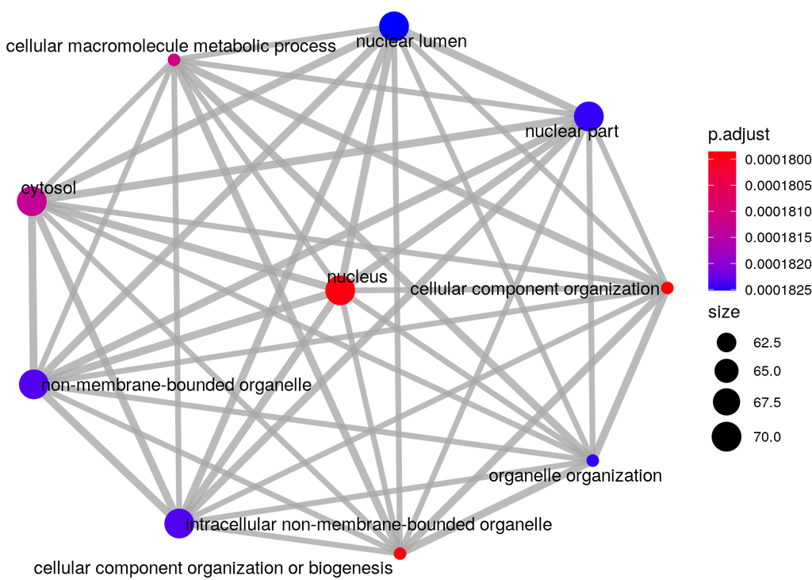

```r
require(pathview)
emapplot(gse, showCategory = 10)
```

use cnetplot in enrichplot package for gene-concept network plot:

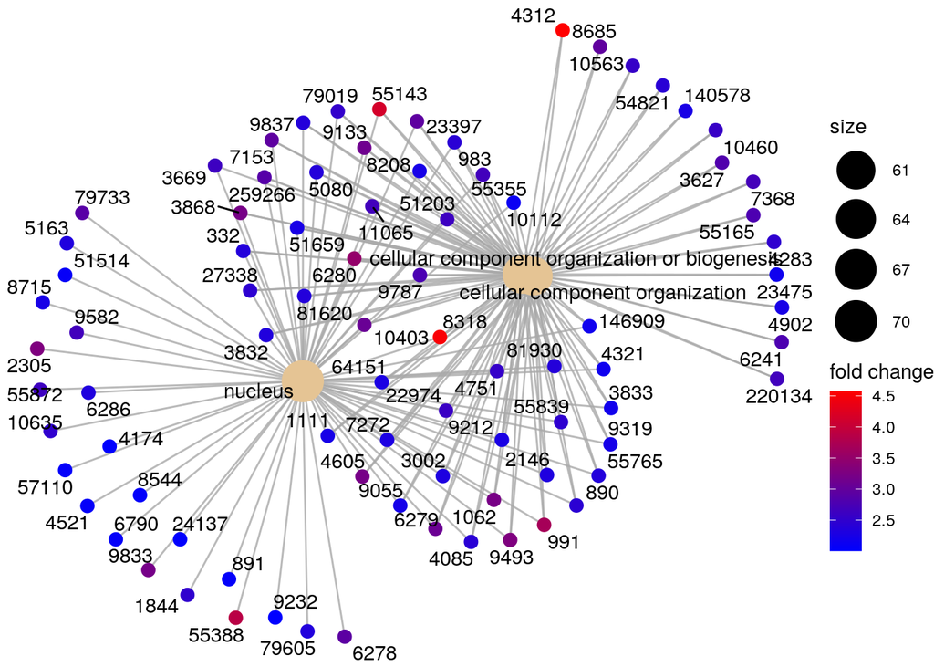

```r
cnetplot(gse, categorySize = 'pvalue', foldChange = DEgenes, showCategory = 3)
```

for ridgeline plot for GSEA result use ridgeplot of enrichplot package:

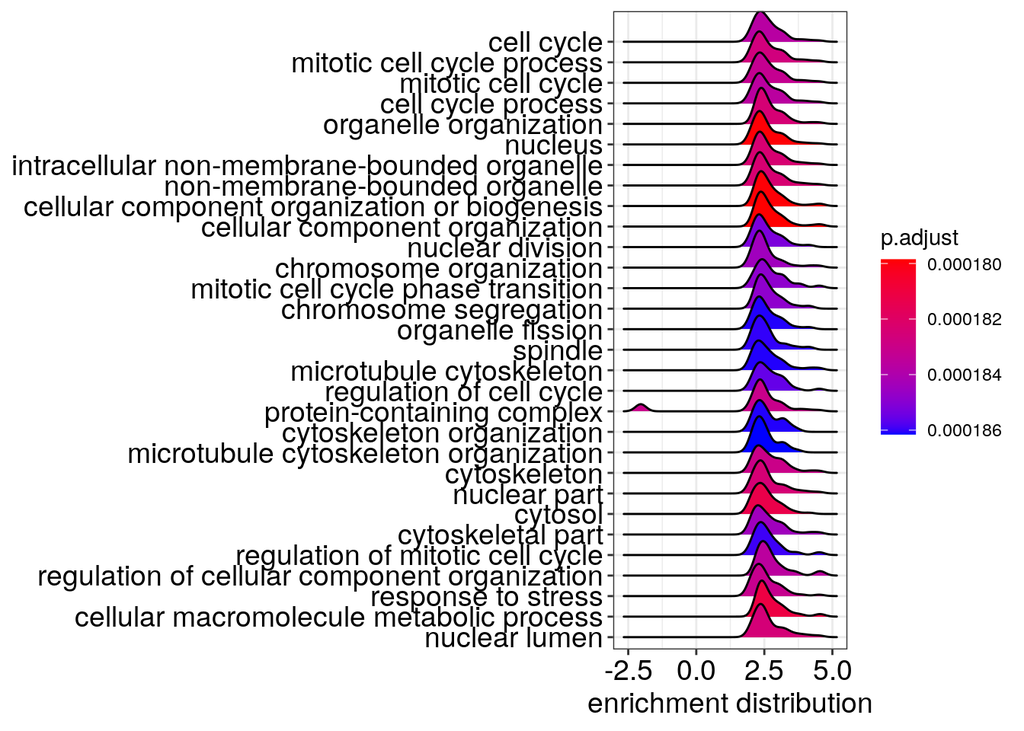

```r
ridgeplot(gse) + labs(x = 'enrichment distribution')
```

for visualizing gsea result use gseaplot in enrichplot package:

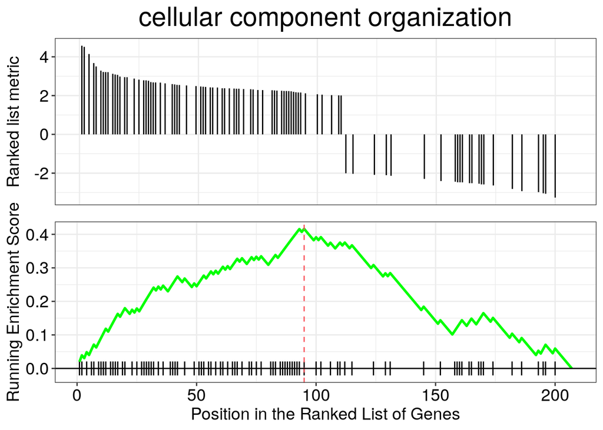

```r
gseaplot(gse, by = 'all', title = gse$Description[1], geneSetID = 1)
```

pmc plot;

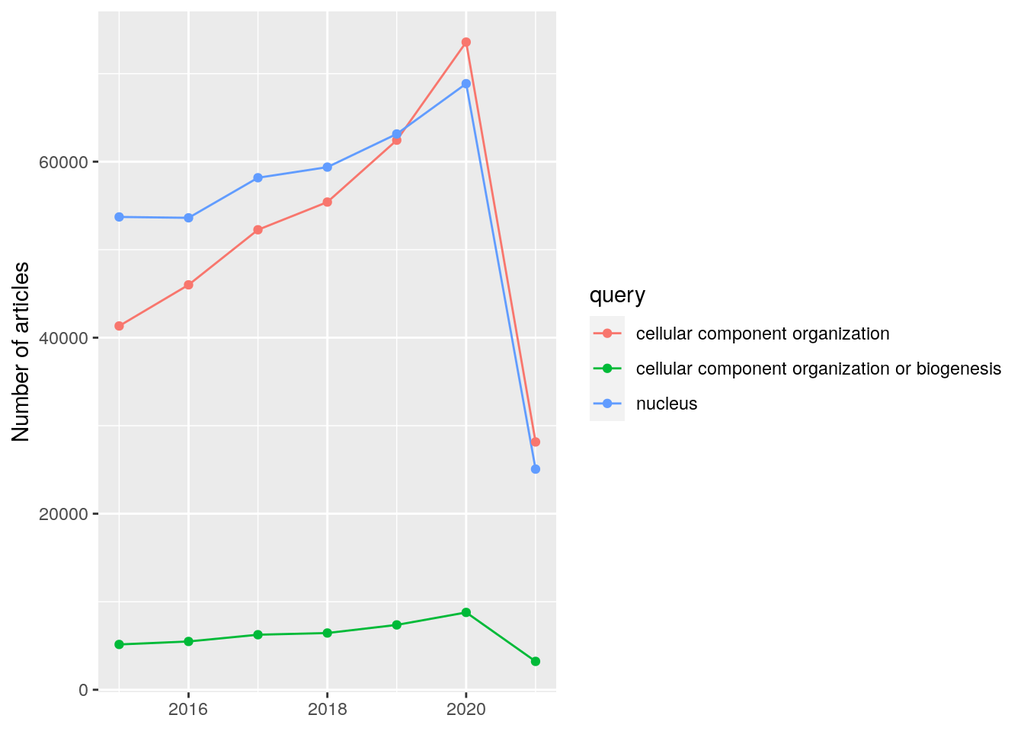

```r
pmcplot(gse$Description[1:3], 2015:2021, proportion =FALSE)
```

### KEGG Gene set enrichment analysis

Homo sapiens kegg code;

```r
library(clusterProfiler)
homo_code <- search_kegg_organism('Homo sapiens', by = 'scientific_name')
head(homo_code)
```

```
##   kegg_code scientific_name common_name
## 1       hsa    Homo sapiens       human
```

KEGG overrepresentation analysis;

```r
ekk <- enrichKEGG(gene = names(DEgenes),
                    organism = 'hsa',
                    pvalueCutoff = 0.05)
head(ekk)
```

```
##                ID                                                   Description
## hsa04110 hsa04110                                                    Cell cycle
## hsa04114 hsa04114                                                Oocyte meiosis
## hsa04218 hsa04218                                           Cellular senescence
## hsa04061 hsa04061 Viral protein interaction with cytokine and cytokine receptor
## hsa03320 hsa03320                                        PPAR signaling pathway
## hsa04914 hsa04914                       Progesterone-mediated oocyte maturation
##          GeneRatio  BgRatio       pvalue     p.adjust       qvalue
## hsa04110     11/95 124/8105 1.812695e-07 3.752279e-05 3.682634e-05
## hsa04114     10/95 129/8105 2.362910e-06 2.445611e-04 2.400219e-04
## hsa04218     10/95 156/8105 1.298492e-05 8.959596e-04 8.793298e-04
## hsa04061      8/95 100/8105 2.033902e-05 1.052544e-03 1.033008e-03
## hsa03320      7/95  76/8105 2.751248e-05 1.139017e-03 1.117876e-03
## hsa04914      7/95 100/8105 1.603386e-04 5.531683e-03 5.429010e-03
##                                                      geneID Count
## hsa04110 8318/991/9133/890/983/4085/7272/1111/891/4174/9232    11
## hsa04114    991/9133/983/4085/51806/6790/891/9232/3708/5241    10
## hsa04218     2305/4605/9133/890/983/51806/1111/891/776/3708    10
## hsa04061           3627/10563/6373/4283/6362/6355/9547/1524     8
## hsa03320                 4312/9415/9370/5105/2167/3158/5346     7
## hsa04914                    9133/890/983/4085/6790/891/5241     7
```

KEGG enrichment analysis:

```r
kea <- gseKEGG(geneList = geneList,
                organism = 'hsa',
                nPerm = 1000,
                minGSSize = 3,
                pvalueCutoff = 0.05)
```

```
## preparing geneSet collections...
```

```
## GSEA analysis...
```

```
## leading edge analysis...
```

```
## done...
```

```r
head(kea)
```

```
##                ID                       Description setSize enrichmentScore
## hsa04151 hsa04151        PI3K-Akt signaling pathway     322      -0.3482755
## hsa04510 hsa04510                    Focal adhesion     190      -0.4169068
## hsa04512 hsa04512          ECM-receptor interaction      81      -0.4663667
## hsa04974 hsa04974  Protein digestion and absorption      80      -0.5303427
## hsa05410 hsa05410       Hypertrophic cardiomyopathy      83      -0.4466565
## hsa00982 hsa00982 Drug metabolism - cytochrome P450      49      -0.5413982
##                NES      pvalue   p.adjust    qvalues rank
## hsa04151 -1.510311 0.001293661 0.03280423 0.02430318 1997
## hsa04510 -1.713648 0.001377410 0.03280423 0.02430318 2183
## hsa04512 -1.687505 0.001577287 0.03280423 0.02430318 1985
## hsa04974 -1.914989 0.001579779 0.03280423 0.02430318 1890
## hsa05410 -1.619051 0.001579779 0.03280423 0.02430318 2917
## hsa00982 -1.794836 0.001639344 0.03280423 0.02430318 1477
##                            leading_edge
## hsa04151 tags=23%, list=16%, signal=20%
## hsa04510 tags=27%, list=17%, signal=22%
## hsa04512 tags=35%, list=16%, signal=29%
## hsa04974 tags=41%, list=15%, signal=35%
## hsa05410 tags=35%, list=23%, signal=27%
## hsa00982 tags=45%, list=12%, signal=40%
##                                                                                                                                                                                                                                                                                                          …
## hsa04151 627/2252/7059/92579/5563/5295/6794/1288/7010/3910/3371/3082/…
## hsa04510                                                                                                                        5595/5228/7424/1499/4636/83660/7059/5295/1288/23396/3910/337…
## hsa04512                                                                                                                                                                                                                                                7059/1288/3910/3371/1291/7450/3685/948/1280/3675/…
## hsa04974                                                                                                                                                                                                                      1288/5547/1291/1301/80781/482/1280/1306/1278/481/1277/81578/4311/1293/1295/…
## hsa05410                                                                                                                                                                                                                                          6543/8515/51422/8516/6546/3672/7169/783/5562/7139/27091…
## hsa00982                                                                                                                                                                                                                                                                                 1576/1571/1558/1…
```

Dotplot:

[figure not shown]

```r
dotplot(kea, showCategory = 10, title = 'Enriched Pathways',
        split = '.sign') + facet_grid(.~.sign)
```

emapplot:

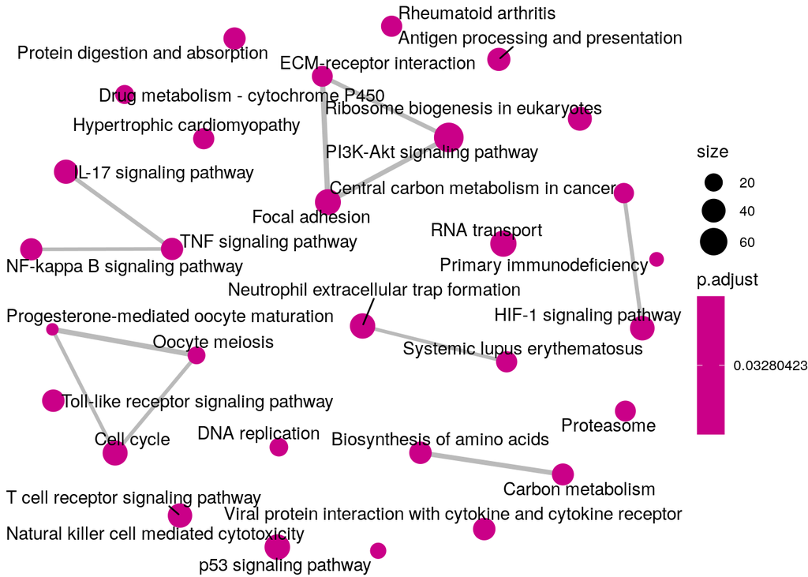

```r
emapplot(kea)
```

Category netplot:

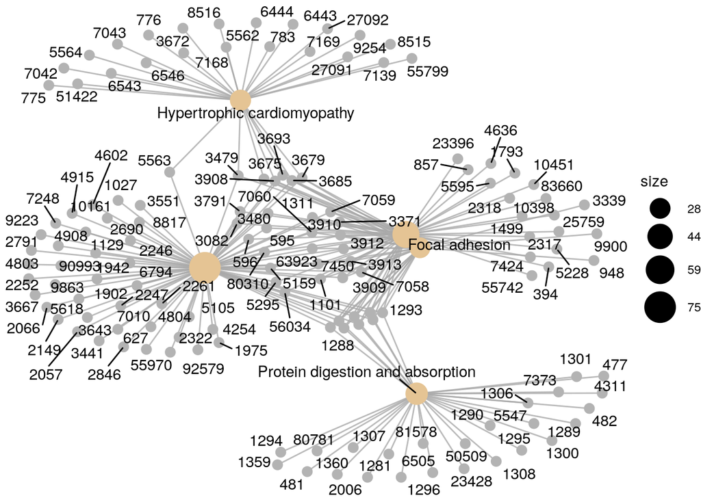

```r
cnetplot(kea, categorySize = 'pvalue', foldchange = geneList)
```

ridgeplot:

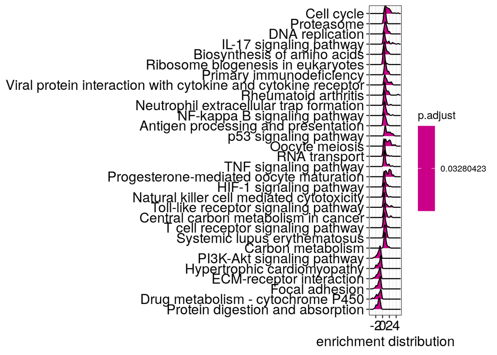

```r
ridgeplot(kea) + labs(x = 'enrichment distribution')
```

GSEA plot:

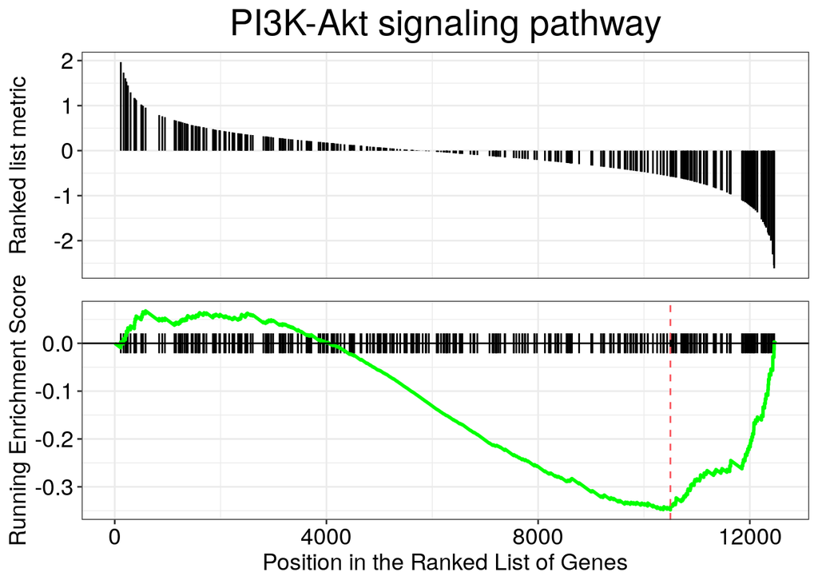

```r
gseaplot(kea, by = 'all', title = kea$Description[1], geneSetID = 1)
```

pathview:

```r
# pathview(gene.data = geneList,pathway.id = 'hsa04510', species = 'hsa', kegg.native = F)
```

```r
pathview(gene.data = geneList,pathway.id = 'hsa04510', species = 'hsa', kegg.native = T)
```

```
## Info: Working in directory /home/mohsen/Temp
```

```
## Info: Writing image file hsa04510.pathview.png
```

```r
pathview(gene.data = geneList,pathway.id = 'hsa04510', species = 'hsa')
```

```
## Info: Working in directory /home/mohsen/Temp
```

```
## Info: Writing image file hsa04510.pathview.png
```

[figure not shown]

```r
knitr::include_graphics('hsa04510.png')
```

[figure not shown]

```r
knitr::include_graphics('hsa04510.pathview.png')
```